# Visualization of Experimental Data - 1

Jay Cho

May 18, 2016

# Synopsis

A good chunk of my daily task of a process engineer involves the followings:

- Data generation from experimental data (mainly from manual measurements of electron micrographs)
- Data analysis
- Draw conclusions for the next set of experiments

It is hence critical for me to be able to perform aforementioned tasks not only effectively but also in a time-optimized fashion.

This is where I found the data science techniques such as ‘Data Visualization’ and ‘Exploratory Data Analysis’ could provide an edge, if I can find a way to transform the manual measurements into a [tidy](https://cran.r-project.org/web/packages/tidyr/vignettes/tidy-data.html) dataset.

After weeks of mundane trial & error, I recently made a significant progress where I was able to visualize/analyze data both in efficiency & effectiveness and hence design of experiments (DOEs).

While still in an explorative stage, the example below shows a snippet of my recent practices at work ([Lam Research](http://www.lamresearch.com/)) where I implemented ‘Data Visualization’ and ‘Exploratory Data Analysis’. Such practice allowed me to explore unforeseen/overlooked insights in complex etch processes required for next-generation semiconductor chips.

# Overview

The experimental data that will be used below is based on a real data but has been modified to protect company & customer confidentialities.

# Data Analysis

## Loading Libraries

```r
#Loading required libraries
library(readxl)
```

```r
library(dplyr)
library(ggplot2)
library(tidyr)
library(gridExtra)
library(grid)
library(Rmisc)
```

## Loading Data

Due to complexity and inconsistency on data generation (e.g: working in collaboration with other engineers, different style and/or numbers of measurement points, etc), I have come to a conclusion that creating a [tidy](https://cran.r-project.org/web/packages/tidyr/vignettes/tidy-data.html) dataset manually first in Excel is inevitable. The data that is being loaded below has been ‘tidied’ up manually in excel.

```r
#Loading tidy data
exp_data <- read_excel("Data_for_Data_Visualization.xlsx")
```

```r
#Getting to know data set
#Looking into the structure of data
str(exp_data)
```

```
## Classes 'tbl_df', 'tbl' and 'data.frame':    328 obs. of  9 variables:
##  $ Sample    : chr  "J07-TEM" "J07-TEM" "J07-TEM" "J09-TEM" ...
##  $ Location  : chr  "Location_1" "Location_2" "Location_3" "Location_1" ...
##  $ Measure_1 : num  17.5 NA NA 16.8 NA ...
##  $ Material_1: num  46 28.6 36.4 43.9 42.5 ...
##  $ Material_2: num  44.5 33.3 41.8 42.4 38.2 ...
##  $ Material_3: num  39.2 30.2 38.4 37.4 33.1 ...
##  $ Material_4: chr  "6.8800000000000008" "9.9333333333333318" "9.6" "10.133333333333335" ...
##  $ Material_5: num  7.75 6.57 7.57 4.5 3.48 ...
##  $ Material_6: num  NA NA 32.1 NA NA ...
```

```r
#Looking into the first 20 inputs
head(exp_data, 20)
```

```
## Source: local data frame [20 x 9]
##
##      Sample   Location Measure_1 Material_1 Material_2 Material_3
##       (chr)      (chr)     (dbl)      (dbl)      (dbl)      (dbl)
## 1   J07-TEM Location_1  17.54388     46.040   44.46000   39.16000
## 2   J07-TEM Location_2        NA     28.600   33.30000   30.23333
## 3   J07-TEM Location_3        NA     36.350   41.75000   38.40000
## 4   J09-TEM Location_1  16.81000     43.860   42.40000   37.42000
## 5   J09-TEM Location_2        NA     42.500   38.20000   33.10000
## 6   J09-TEM Location_3        NA     57.375   53.87500   47.77500
## 7   J10-TEM Location_1  17.58273     34.520   34.96000   25.98000
## 8   J10-TEM Location_2        NA     50.600   41.20000   33.40000
## 9   J10-TEM Location_3        NA     76.075   57.25000   45.82500
## 10  J11-TEM Location_1  17.54388     30.820   29.52000   18.38000
## 11  J11-TEM Location_2        NA     47.000   36.80000   26.06667
## 12  J11-TEM Location_3        NA     76.300   57.25714   40.40000
## 13  J12-TEM Location_1  18.13455     38.270   38.27000   28.70000
## 14  J12-TEM Location_2        NA     51.700   39.83333   31.21667
## 15  J12-TEM Location_3        NA     81.800   73.60000   34.40000
## 16  J13-TEM Location_1  18.48000     44.800   42.96000   36.48000
## 17  J13-TEM Location_2        NA     37.400   37.16667   33.30000
## 18  J13-TEM Location_3        NA     52.600   48.00000   43.00000
## 19 R12-STEM Location_1  19.82500     34.575   35.30000   33.16667
## 20 R12-STEM Location_2  46.10000     25.120   31.90000   29.46667
## Variables not shown: Material_4 (chr), Material_5 (dbl), Material_6 (dbl)
```

## Preparing Data

One of the greatest advantages of using R instead of Excel/Origin lies in the flexibility and speed at which different types of plots can be generated. The examples below show how high-quality plots can be generated by a few lines of code on the fly.

### Data Processing

Let’s say there are two samples of our interest:

- R47 : Some baseline process
- R116 : R47 + additional procedure has been executed

But first, our dataset ‘exp_data’ actually contains the sample names with the type of metrology techniques used to obtain data with a hyphen (-) in the column ‘Sample’.

We therefore first need to separate this ‘Sample’ column into two, to ‘Sample’ and ‘Metrology’.

Let’s make a new column called “Metrology” and separate such info from the sample name:

```r
#Taking "Sample"" column and separating into "Sample" and "Metrology"
exp_data <- separate(exp_data,Sample,c("Sample","Metrology"),sep="-")
exp_data
```

```
## Source: local data frame [328 x 10]
##
##    Sample Metrology   Location Measure_1 Material_1 Material_2 Material_3
##     (chr)     (chr)      (chr)     (dbl)      (dbl)      (dbl)      (dbl)
## 1     J07       TEM Location_1  17.54388     46.040     44.460   39.16000
## 2     J07       TEM Location_2        NA     28.600     33.300   30.23333
## 3     J07       TEM Location_3        NA     36.350     41.750   38.40000
## 4     J09       TEM Location_1  16.81000     43.860     42.400   37.42000
## 5     J09       TEM Location_2        NA     42.500     38.200   33.10000
## 6     J09       TEM Location_3        NA     57.375     53.875   47.77500
## 7     J10       TEM Location_1  17.58273     34.520     34.960   25.98000
## 8     J10       TEM Location_2        NA     50.600     41.200   33.40000
## 9     J10       TEM Location_3        NA     76.075     57.250   45.82500
## 10    J11       TEM Location_1  17.54388     30.820     29.520   18.38000
## ..    ...       ...        ...       ...        ...        ...        ...
## Variables not shown: Material_4 (chr), Material_5 (dbl), Material_6 (dbl)
```

Now that the sample names has been separated, let’s filter out the samples of interst, R47 and R116:

```r
selected_data <- filter(exp_data,Sample %in% c("R47","R116"))

selected_data
```

```
## Source: local data frame [8 x 10]
##
##   Sample Metrology   Location Measure_1 Material_1 Material_2 Material_3
##    (chr)     (chr)      (chr)     (dbl)      (dbl)      (dbl)      (dbl)
## 1    R47      STEM Location_1  22.98750   30.41250   23.12500   16.77500
## 2    R47      STEM Location_2        NA   29.90000   29.48333   25.41667
## 3    R47      STEM Location_3        NA   33.80000   32.47500   26.35000
## 4    R47      STEM Location_4        NA   42.45000   41.95000   36.45000
## 5   R116      STEM Location_1  22.61667   36.55000   38.78333   32.20000
## 6   R116      STEM Location_2        NA   36.47143   36.77143   28.00000
## 7   R116      STEM Location_3        NA   34.25000   35.90000   26.65000
## 8   R116      STEM Location_4        NA   49.40000   46.10000   38.75000
## Variables not shown: Material_4 (chr), Material_5 (dbl), Material_6 (dbl)
```

Now that the data only from our samples of interest has been selected, we can change this data to a [long format](http://www.cookbook-r.com/Manipulating_data/Converting_data_between_wide_and_long_format/). Using a long format data is required for flexbility in plotting in ggplot2 package, which will be shown in the later sections.

```r
#Gathering all measurements into a column called 'Value'
selected_data_long <- gather(selected_data,Measurement,Value,4:10)

selected_data_long
```

```
## Source: local data frame [56 x 5]
##
##    Sample Metrology   Location Measurement            Value
##     (chr)     (chr)      (chr)       (chr)            (chr)
## 1     R47      STEM Location_1   Measure_1          22.9875
## 2     R47      STEM Location_2   Measure_1               NA
## 3     R47      STEM Location_3   Measure_1               NA
## 4     R47      STEM Location_4   Measure_1               NA
## 5    R116      STEM Location_1   Measure_1 22.6166666666667
## 6    R116      STEM Location_2   Measure_1               NA
## 7    R116      STEM Location_3   Measure_1               NA
## 8    R116      STEM Location_4   Measure_1               NA
## 9     R47      STEM Location_1  Material_1          30.4125
## 10    R47      STEM Location_2  Material_1             29.9
## ..    ...       ...        ...         ...              ...
```

```r
#Since 'Value' is marked as a character. We need to change this to numeric:
selected_data_long$Value <- as.numeric(selected_data_long$Value)

selected_data_long
```

```
## Source: local data frame [56 x 5]
##
##    Sample Metrology   Location Measurement    Value
##     (chr)     (chr)      (chr)       (chr)    (dbl)
## 1     R47      STEM Location_1   Measure_1 22.98750
## 2     R47      STEM Location_2   Measure_1       NA
## 3     R47      STEM Location_3   Measure_1       NA
## 4     R47      STEM Location_4   Measure_1       NA
## 5    R116      STEM Location_1   Measure_1 22.61667
## 6    R116      STEM Location_2   Measure_1       NA
## 7    R116      STEM Location_3   Measure_1       NA
## 8    R116      STEM Location_4   Measure_1       NA
## 9     R47      STEM Location_1  Material_1 30.41250
## 10    R47      STEM Location_2  Material_1 29.90000
## ..    ...       ...        ...         ...      ...
```

```r
#selected_data_long as additional measurement values under 'Measure_1' which is irrelevant in this example. Hence 'Measure_1' values will be removed hereon:

selected_data_long <- filter(selected_data_long,Measurement!="Measure_1")
selected_data_long
```

```
## Source: local data frame [48 x 5]
##
##    Sample Metrology   Location Measurement    Value
##     (chr)     (chr)      (chr)       (chr)    (dbl)
## 1     R47      STEM Location_1  Material_1 30.41250
## 2     R47      STEM Location_2  Material_1 29.90000
## 3     R47      STEM Location_3  Material_1 33.80000
## 4     R47      STEM Location_4  Material_1 42.45000
## 5    R116      STEM Location_1  Material_1 36.55000
## 6    R116      STEM Location_2  Material_1 36.47143
## 7    R116      STEM Location_3  Material_1 34.25000
## 8    R116      STEM Location_4  Material_1 49.40000
## 9     R47      STEM Location_1  Material_2 23.12500
## 10    R47      STEM Location_2  Material_2 29.48333
## ..    ...       ...        ...         ...      ...
```

```r
#While the [categorial variables] (https://en.wikipedia.org/wiki/Categorical_variable) in our data (e.g: Sample, Location, and Measurement Type) are not really ordinal variables, we'll force it to be ordinal variables

selected_data_long$Sample <- factor(selected_data_long$Sample, levels=c("R47","R116"))
selected_data_long$Location <- factor(selected_data_long$Location, levels=c("Location_1","Location_2","Location_3","Location_4"))
selected_data_long$Measurement <- factor(selected_data_long$Measurement, levels=c("Material_1","Material_2","Material_3","Material_4","Material_5","Material_6"))
```

## Data Plotting

We can visualize this long-formatted data with a beautiful [ggplot2](http://docs.ggplot2.org/current/) package.

### Measurement Value vs. Location (per Sample)

The first plot to be plotted is ‘Measurement Value vs Location (per Sample)’, which provides an effective visual medium as to how Sample R116 differs from R47:

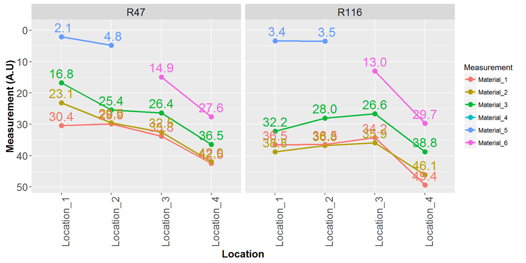

Figure 1. Measurement Value vs. Location (per Sample)

```r
  depth_selected_lineplot <<- selected_data_long %>%
    ggplot(aes(x=Location,y=Value,color=Measurement,group=Measurement,
        label=format(round(Value,1),nsmall=1))) +
        geom_point(size=3) + geom_line(size=1) +
        labs(y="Measurement (A.U)") +
        facet_grid(~Sample) + geom_text(size=6,show.legend=F, nudge_y=3) +
        scale_y_continuous(trans = "reverse") +
            theme(axis.text=element_text(size=14),
            axis.text.x=element_text(angle=90, hjust = 1),
            axis.title=element_text(size=14,face="bold"),
            plot.title=element_text(size=16,face="bold"),
            strip.text.x = element_text(size = 14),
            strip.text.y = element_text(size = 14)
            )

depth_selected_lineplot
```

One might question whether using R is any beneficial at this point far, as the figure above can be plotted in Excel and Origin.

The real benefit of using R lies in the flexibility on the speed of these plots can be generated.

Let’s plot the same data a little differently, by Measurement Value vs. Sample (per Location)

### Measurement Value vs. Sample (per Location)

By plotting the same data as ‘Measurement Value vs. Sample (per Location)’, it is really easy to visualize how each materials change at a given location between the two samples:

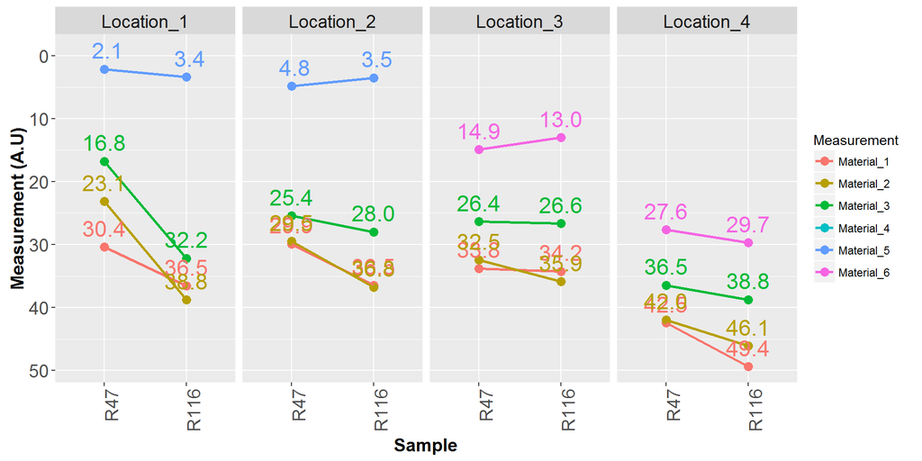

Figure 2. Measurement Value vs. Sample (per Location)

```r
  depth_selected_line_changeplot <<- selected_data_long %>%
    ggplot(aes(x=Sample,y=Value,color=Measurement,group=Measurement,
        label=format(round(Value,1),nsmall=1))) +
        geom_point(size=3) + geom_line(size=1) +
        labs(y="Measurement (A.U)") +
        facet_grid(~Location) + geom_text(size=6,show.legend=F, nudge_y=3) +
        scale_y_continuous(trans = "reverse") +
            theme(axis.text=element_text(size=14),
            axis.text.x=element_text(angle=90, hjust = 1),
            axis.title=element_text(size=14,face="bold"),
            plot.title=element_text(size=16,face="bold"),
            strip.text.x = element_text(size = 14),
            strip.text.y = element_text(size = 14)
            )

depth_selected_line_changeplot
```

By comparing Fig 2 vs. Fig 1, it is evident that Fig 2 is much more effetive in determining which materials (between the two samples) have changed at each location without the need of reading the measurement values off from previous figure (Figure 1) and/or Excel tables.

## Additional Comments

The current code I use daily builds on the scaffold codes shown here, with differences of: Various plot generations have been defined as functions. Such plots include:

- Selectivity
- [Macro & Microloadings](http://www.vlsi-expert.com/2015/07/effects-of-etching-process-part2.html)
- et cetera

For example, the etch selectivities (the ratio of etching rates of different materials at identical plasma conditions) of each material can also be analyzed in a straight forward manner:

Let’s look into etch selectivity of Material 1 over Material 2, defined as S = $ER_{Material_1}$/$ER_{Material_2}$

```r
#The selectivity of Material 1 over Material 2 will be calculated by creating new column named Sel_Mat1_Mat2 on 'selected_data' dataframe.

#Note: While the definition of selectivity is based on the etch rate, since the experiment was performed over the same time interval, the etch depths can be used directly

#Creating a new column using 'mutate' function from 'dplyr' package
selected_data <- mutate(selected_data,Sel_Mat1_Mat2=Material_1/Material_2)

selected_data
```

```
## Source: local data frame [8 x 11]
##
##   Sample Metrology   Location Measure_1 Material_1 Material_2 Material_3
##    (chr)     (chr)      (chr)     (dbl)      (dbl)      (dbl)      (dbl)
## 1    R47      STEM Location_1  22.98750   30.41250   23.12500   16.77500
## 2    R47      STEM Location_2        NA   29.90000   29.48333   25.41667
## 3    R47      STEM Location_3        NA   33.80000   32.47500   26.35000
## 4    R47      STEM Location_4        NA   42.45000   41.95000   36.45000
## 5   R116      STEM Location_1  22.61667   36.55000   38.78333   32.20000
## 6   R116      STEM Location_2        NA   36.47143   36.77143   28.00000
## 7   R116      STEM Location_3        NA   34.25000   35.90000   26.65000
## 8   R116      STEM Location_4        NA   49.40000   46.10000   38.75000
## Variables not shown: Material_4 (chr), Material_5 (dbl), Material_6 (dbl),
##   Sel_Mat1_Mat2 (dbl)
```

```r
#Will subset needed columns only, in this case 'Sample','Location', and 'Sel_Mat1_Mat2'
selectivity_data <- selected_data[,c(1,3,11)]

#And transform the sample names into an ordinal variable:
selectivity_data$Sample <- factor(selectivity_data$Sample, levels=c("R47","R116"))
```

Now the selectivity of Material_1 over Material_2 can be plotted in a similar fashion to Fig 1 and Fig 2:

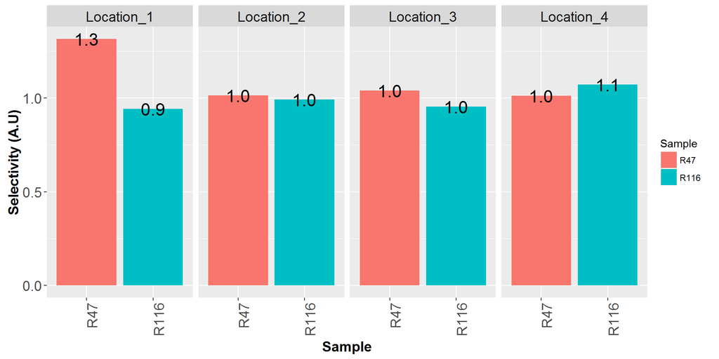

Figure 3. Selectivity (Material_1 over Material_2) vs. Sample (per Location)

```r
  selectivity_plot <-
    ggplot(selectivity_data,aes(x=Sample,y=Sel_Mat1_Mat2,label=format(round(Sel_Mat1_Mat2,1),nsmall=1),
                 fill=Sample))+geom_bar(stat="identity",position=position_dodge())+
                 labs(y="Selectivity (A.U)") + facet_grid(~Location) +
                  geom_text(size=6,show.legend=F, position=position_dodge(width=1)) +
                    theme(axis.text=element_text(size=14),
                    axis.text.x=element_text(angle=90, hjust = 1),
                    axis.title=element_text(size=14,face="bold"),
                    plot.title=element_text(size=16,face="bold"),
                    strip.text.x = element_text(size = 14))

  selectivity_plot
```

As evident from Figure 3, sample R116 resulted in a significant reduction (~30%) of Material_1’s selectivity over Material_2 only at Location_1.

To draw a similar graph on Excel or Origin is still doable. However, it not only will take much longer time than R, but also requires additional time modify the graph aesthetics between the 4 graphs generated with respect to each location.

# Concluding Remarks

The dataset & figures shown in these examples have been very limited as I cannot share much of corporate data owing to corporate/customer confidentiality. Yet, I hope this gave a brief introduction/taste on how one can implement R for effective data visualizations/analyses for those in a similar field.